# Loan Granting Binary Classification

### Microsoft Cortana Challenge

### Can we predict whether a customer will be able to fully repay a loan?

### PROBLEM CONTEXT

When a customer applies for a loan, banks and other credit providers use statistical models to determine whether or not to grant the loan based on the likelihood of the loan being repaid. The factors involved in determining this likelihood are complex, and extensive statistical analysis and modelling are required to predict the outcome for each individual case. I will implement a model that predicts loan repayment or default based on the data provided.

### DATA

The dataset used in this competition consists of synthetic data that was generated specifically for use in this project. The data is designed to exhibit similar characteristics to genuine loan data. The dataset consists of over 255,000 loan records and 19 columns(attributes). The dataset can be downloaded as a csv file by clicking [here](https://az754797.vo.msecnd.net/competition/lex/data/LoansTrainingSet.csv) and a description of the attributes of the dataset can be obtained [here](https://gallery.cortanaintelligence.com/Competition/Loan-Granting-Binary-Classification-1).

```python
raw_data.head(2)
```

|  | Loan ID | Customer ID | Loan Status | Current Loan Amount | Term | Credit Score | Years in current job | Home Ownership | Annual Income | Purpose | Monthly Debt | Years of Credit History | Months since last delinquent | Number of Open Accounts | Number of Credit Problems | Current Credit Balance | Maximum Open Credit | Bankruptcies | Tax Liens |
| --- | --- | --- | --- | --- | --- | --- | --- | --- | --- | --- | --- | --- | --- | --- | --- | --- | --- | --- | --- |
| 0 | 000025bb-5694-4cff-b17d-192b1a98ba44 | 5ebc8bb1-5eb9-4404-b11b-a6eebc401a19 | Fully Paid | 11520 | Short Term | 741.0 | 10+ years | Home Mortgage | 33694.0 | Debt Consolidation | $584.03 | 12.3 | 41.0 | 10 | 0 | 6760 | 16056 | 0.0 | 0.0 |
| 1 | 00002c49-3a29-4bd4-8f67-c8f8fbc1048c | 927b388d-2e01-423f-a8dc-f7e42d668f46 | Fully Paid | 3441 | Short Term | 734.0 | 4 years | Home Mortgage | 42269.0 | other | $1,106.04 | 26.3 | NaN | 17 | 0 | 6262 | 19149 | 0.0 | 0.0 |

### DATA EXPLORATION

This is an overview of the data exploration I carried out to understand outliers, missing values in the different features and treat them.

- **LOAN IDs**

We expect each record to have a unique Loan ID since they are applications for different loans. However we find that there are duplicate records in the dataset, which will need cleaning.

```python
print 'Number of total Loan Records is {}'.format(len(raw_data['Loan ID']))
print 'Number of Unique Loan IDs is {}'.format(raw_data['Loan ID'].nunique())
```

```
Number of total Loan Records is 256984
Number of Unique Loan IDs is 215700
```

```python
raw_data['Loan ID'].value_counts().head(5)
```

```
de5e38c0-5e62-46c1-87f0-e412dc59140c    4
a71fc37a-2be4-4740-abad-a8084f4c4310    4
f14d2349-dd5a-4dfe-a595-912483a27a0d    4
b624940f-da82-410b-b885-77d92c2e4f0c    4
9fa4e052-1e55-42d8-bf98-e8e387f02b97    4
Name: Loan ID, dtype: int64
```

Below is the function I wrote to combine the repeated records for each Loan ID into one unique record each and then combine them with the records with unique Loan IDs, to get a dataframe with all unique Loan IDs.

```python
unique_records = df[df['Loan ID'].isin(unique_LoanIDs)]
repeated_records = df[df['Loan ID'].isin(repeated_LoanIDs)]

def merge_repeated_records(group):
    combined_record={}
    for col in group.columns:
        if (group[col].dtype=='float64'):
            combined_record[col] = group[col].dropna().median()
        elif (group[col].dtype=='int64'):
            l = group[col].values.tolist()
            combined_record[col] = int(max(set(l),key=l.count))
        else:
            l = group[col].values.tolist()
            combined_record[col] = max(set(l),key=l.count)
    return combined_record

cleaned_records = pd.DataFrame(repeated_records.groupby('Loan ID').apply(merge_repeated_records).values.tolist())


processed_df = pd.concat([unique_records,cleaned_records],ignore_index=True)[raw_data.columns]
```

- **CREDIT SCORE**

Credit Score values are expected to be in the range of 0 to 800. However the histogram shows a few outliers and looks like the outliers can be treated by dividing them by 10.

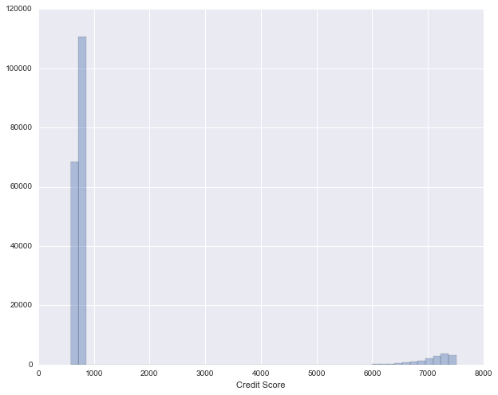

```python
sns.distplot(raw_data['Credit Score'].dropna(),kde=False)
```

- **CURRENT LOAN AMOUNT**

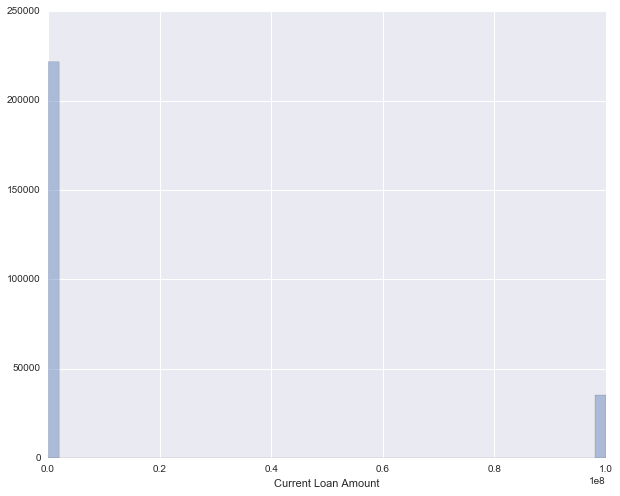

```python
sns.distplot(raw_data['Current Loan Amount'],kde=False)
```

- **HOME OWNERSHIP**

We see that there are two separate categories for 'Home Mortgage' and 'HaveMortgage' which can be combined

```python
raw_data['Home Ownership'].value_counts()
```

```
Home Mortgage    124477
Rent             109010
Own Home          22923
HaveMortgage        574
Name: Home Ownership, dtype: int64
```

- **PURPOSE**

We see that there are two separate categories for 'other' and 'Other' which can be combined

```python
raw_data['Purpose'].value_counts()
```

```
Debt Consolidation      203911
Home Improvements        14915
other                    14268
Other                     9667
Business Loan             4712
Buy a Car                 3276
Medical Bills             2868
Take a Trip               1570
Buy House                 1530
Educational Expenses       267
Name: Purpose, dtype: int64
```

- **MAXIMUM OPEN CREDIT**

We need to impute the missing values for this feature, but since it is skewed we can't use the mean directly, instead we will log transform to convert the distribution into a normal distribution

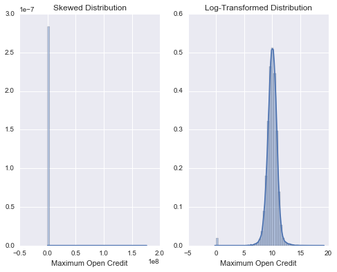

```python
f, axarr = plt.subplots(1,2)
sns.distplot(df['Maximum Open Credit'].dropna(),ax=axarr[0])
axarr[0].set_title('Skewed Distribution')
sns.distplot(np.log(1+df['Maximum Open Credit'].dropna()),ax=axarr[1])
axarr[1].set_title('Log-Transformed Distribution')
```

Find a more comprehensive exploratory analysis in the Data Exploration Notebook

And the code for cleaning the dataset can be found in the Data Cleaning Notebook

### INSIGHTS

This is an overview of the data exploration I carried out to gain insights into the data for feature engineering.

- **CREDIT SCORE**

A look at the distribution of credit scores for customers who fully repaid their loans and those that did not shows a clear distinction.

Customers with **Credit Score < 500** were all found to have failed to repay their loan.

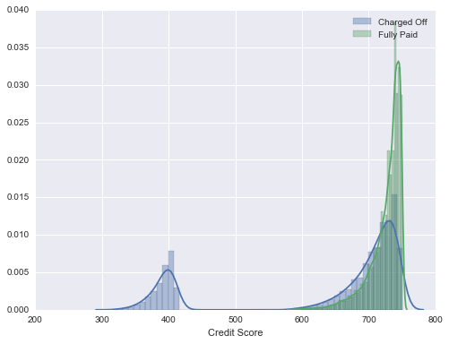

```python
sns.distplot(df.loc[df['Loan Status']=='Charged Off','Credit Score'].dropna())
sns.distplot(df.loc[df['Loan Status']=='Fully Paid','Credit Score'].dropna())
plt.legend(['Charged Off','Fully Paid'])
```

Whether or not the **credit score for an applicant was present or missing** also seemed to be an important feature in determining if the loan was repaid or not, since most applicants whose credit score was absent repaid the loan

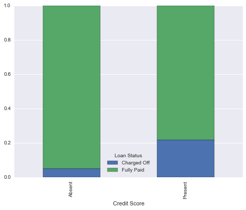

```python
df.groupby([df['Credit Score'].notnull(),'Loan Status']).size().unstack().rename(index={False:'Absent',True:'Present'}).T\
.apply(lambda x: x/x.sum()).T.plot(kind='bar',stacked=True)
```

- **PURPOSE**

We observe that the percentage of loan defaults is significantly more when the **purpose** is **Business Loan** as compared to other categories. Hence this can be a feature we can engineer

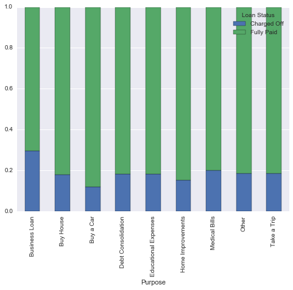

```python
a=df[df['Credit Score']>500]
df.groupby(['Loan Status','Purpose']).size().unstack(1).apply(lambda x: x/np.sum(x),axis=0).T.plot(kind='bar',stacked=True)
```

- **YEARS IN CURRENT JOB**

We observe that the percentage of loan defaults is significantly more when the **Years in current job** is **n/a** as compared to other categories. Hence this can be a useful feature

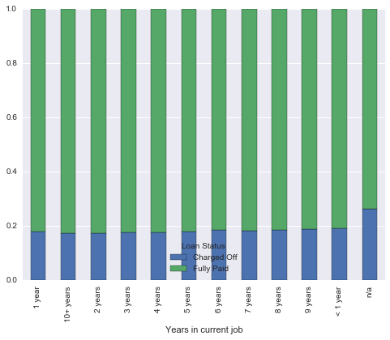

```python
df.groupby(['Loan Status','Years in current job']).size().unstack(1).apply(lambda x: x/np.sum(x),axis=0).T.plot(kind='bar',stacked=True)
```

Find a more comprehensive analysis in the Feature Engineering Notebook

### MODELLING RESULTS

Having created a cleaned dataframe and binding the engineered features I used the **Random Forest Classifier model** from the [scikit-learn module](http://scikit-learn.org/stable/modules/generated/sklearn.ensemble.RandomForestClassifier.html#sklearn.ensemble.RandomForestClassifier) in python. I tuned its parameters using gridsearch and obtained an estimate of the performance of the model using the 'Out-of-box' error for the cross-validations. The **oob score (substitute for CV score) was 0.83**.

Next I used the fitted model, to **predict on the test set** which was held out during the training process. The model performed pretty well with an **accuracy of 84.8%**. In an unbalanced dataset, the F-score is a better metric to optimise compared to the accuracy. The **F-score for the predictions was 0.39**, which can be bettered by using grid search to optimize on f-score rather than oob score, which is the default.

```python
params = {'n_estimators':range(10,35,3),'criterion':('gini','entropy'),'max_depth':[2,3,4],'max_features':range(5,12)}
skf_cv = StratifiedKFold(ytrain,n_folds=10,random_state=7)
clf = GridSearchCV(cv=skf_cv,estimator=rfr,param_grid=params)

clf.fit(X_train.values,ytrain)

clf.oob_score_
```

```
0.83115438108484008
```

```python
y_pred = rfr.predict(X_test)
print 'Accuracy of the Random Forest Model is {}'.format(accuracy_score(ytest,y_pred))
print 'F-1 score of the prediciton model is {}'.format(f1_score(ytest,y_pred))
```

```
Accuracy of the Random Forest Model is 0.848493277701
F-1 score of the prediciton model is 0.393647023898
```

While **deploying a model commercially or in production it is important that the model be interpretable**. I looked at the **feature importance** in our fitted model to see how well it matches with our guess regarding the kinds of features which would be useful.

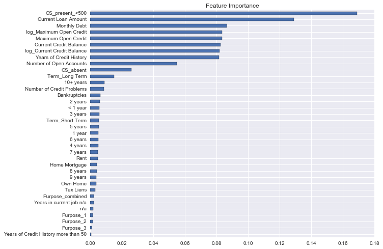

```python
s = pd.Series(rfr.feature_importances_,index = X_train.columns)
s.sort_values(ascending=True).plot(kind='barh')
plt.title('Feature Importance')
```

It turns out that our **intuition about Credit scores being an important attribute was spot on** while one of the features I engineered 'Years of Credit History more than 50' didn't help the model too much and may be discarded in future iterations.

### MY LEARNINGS

1. The dataset gave me a chance to practice my **data wrangling skills with pandas**.
2. I established an **iterative workflow using IPython notebooks** and pickling dataframes. I used one notebook each for the 4 stages of modelling:
   - Data Import & Exploration
   - Data Cleaning
   - Feature Engineering
   - Modelling & Prediction
3. The processed dataframe at the end of each notebook was pickled and read in as input in the next stage. This way the code could be easily added to any stage while still maintaining continuity in the analysis.
4. Explored the various **visualisations** provided by **seaborn** module.